# Reproducible Research - Week2

Pranab Niyogi

December 13, 2016

### Setup directory, load libraries

### 1. Loading and preprocessing the data

```r
dfActivity <- read.csv("activity.csv");
dfActivity <- dfActivity[!is.na(dfActivity$steps),]
```

### 2. What is mean total number of steps taken per day?

#### 2.1 Show the Histogram

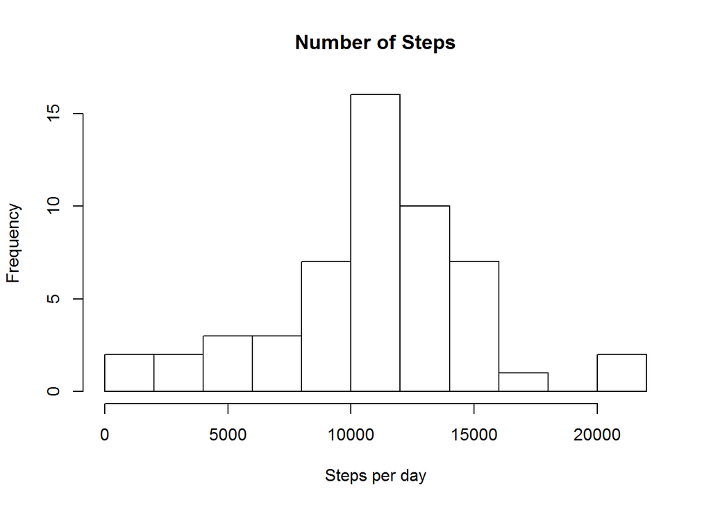

```r
dfActivitySum <- aggregate(dfActivity$steps, by=list(dfActivity$date),FUN=sum)
names(dfActivitySum) <- c("Date","Steps")
hist(dfActivitySum$Steps,breaks=10, main="Number of Steps", xlab="Steps per day")
```

#### 2.2 Calculate and report the mean and median of the total number of steps taken per day

```r
dfActivitySumByDate <- aggregate(dfActivity$steps,by=list(dfActivity$date),FUN=sum)
names(dfActivitySumByDate) <- c("Date","steps")
# Mean
mean(dfActivitySumByDate$steps,na.rm=TRUE)
```

```
## [1] 10766.19
```

```r
# Median
median(dfActivitySumByDate$steps,na.rm=TRUE)
```

```
## [1] 10765
```

### 3. What is the average daily activity pattern?

#### 3.1 Make a time series plot (i.e. type = “l”) of the 5-minute interval (x-axis) and the average number of steps taken, averaged across all days (y-axis)

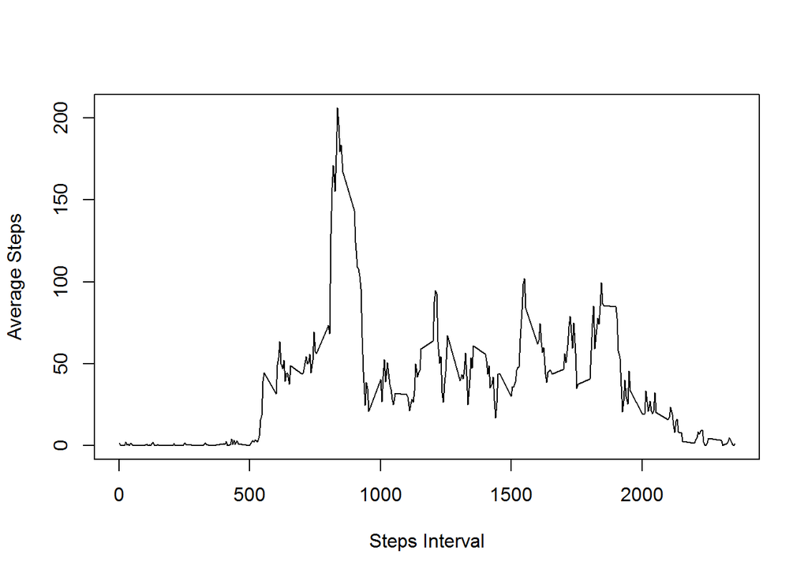

```r
dfActivityMeanByInterval <- aggregate(dfActivity$steps,by=list(dfActivity$interval),FUN=mean)
names(dfActivityMeanByInterval) <- c("Interval","Steps" )
 plot(dfActivityMeanByInterval$Interval,dfActivityMeanByInterval$Steps, type='l',xlab="Steps Interval",ylab="Average Steps")
```

#### 3.2 Which 5-minute interval, on average across all the days in the dataset, contains the maximum number of steps?

```r
dfActivityMeanByInterval[dfActivityMeanByInterval$Steps==max(dfActivityMeanByInterval$Steps),]
```

```
##     Interval    Steps
## 104      835 206.1698
```

### 4. Imputing missing values

#### 4.1 Calculate and report the total number of missing values in the dataset (i.e. the total number of rows with NAs)

```r
dfActivity <- read.csv("activity.csv");
nrow(dfActivity[is.na(dfActivity$steps),])
```

```
## [1] 2304
```

#### 4.2 Devise a strategy for filling in all of the missing values in the dataset.

```
    Used average of 5 min interval accross dates to fillup the missing values
```

#### 4.3 Create a new dataset that is equal to the original dataset but with the missing data filled in.

```r
dfActivity <- read.csv("activity.csv");
dfActivity1 <- dfActivity[!is.na(dfActivity$steps),]

avgperday <- aggregate(dfActivity1$steps,by=list(factor(as.character(dfActivity1$interval))), FUN=mean)
  for ( i in 1:nrow(dfActivity) )
  {
    if (is.na(dfActivity[i,1]))
    {

      dfActivity[i,1] <- avgperday[which(dfActivity[i,3]==avgperday$Group.1),2]
    }

  }
```

#### 4.4 Make a histogram of the total number of steps taken each day

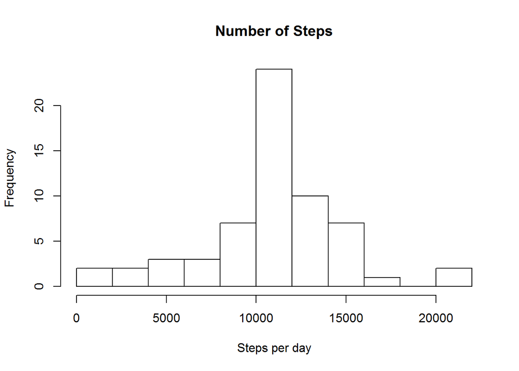

```r
dfActivitySumByDate <- aggregate(dfActivity$steps,by=list(dfActivity$date),FUN=sum)
names(dfActivitySumByDate) <- c("Date","steps")
hist(dfActivitySumByDate$steps,breaks=10, main="Number of Steps", xlab="Steps per day")
```

#### 4.4.1 Calculate and report the mean and median total number of steps taken per day.Do these values differ from the estimates from the first part of the assignment?

```r
# Mean
mean(dfActivitySumByDate$steps,na.rm=TRUE)
```

```
## [1] 10766.19
```

```r
# Median
median(dfActivitySumByDate$steps,na.rm=TRUE)
```

```
## [1] 10766.19
```

#### 4.4.2 What is the impact of imputing missing data on the estimates of the total daily number of steps?

#### Estimating missing data Did not skewed the statistics.

### 5.0 Are there differences in activity patterns between weekdays and weekends?

#### 5.1 Create a new factor variable in the dataset with two levels - “weekday” and “weekend” indicating whether a given date is a weekday or weekend day.

```r
dfActivity$day <- "weekday"
for (i in 1:nrow(dfActivity) )
{
  if ( weekdays(as.Date(dfActivity[i,2]),abb=T) %in% c("Sat","Sun") )
  {
   dfActivity[i,4] <- "weekend"
  }
}
```

#### 5.2 Make a panel plot containing a time series plot (i.e. type = “l”) of the 5-minute interval (x-axis) and the average number of steps taken, averaged across all weekday days or weekend days (y-axis).

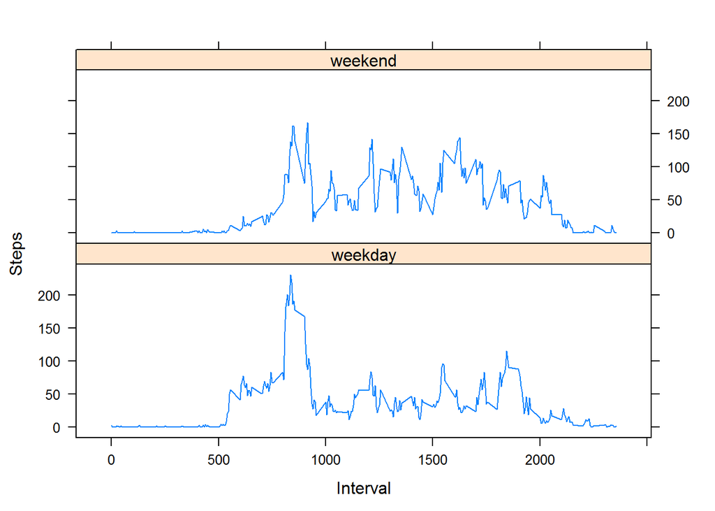

```r
library(lattice)
dfActivityByDOW <- aggregate(dfActivity$steps,by=list(dfActivity$interval,dfActivity$day), FUN="mean")
names(dfActivityByDOW) <- c("interval","day","steps")
xyplot(steps ~ interval | day, data=dfActivityByDOW, type="l", layout=c(1,2), xlab="Interval",ylab="Steps")
```